# Python - Data Scientist Program

#### Autor: Adrian Sanhueza

#### Date: December 2019

# 8 - Introduction to Natural Laguage Processing (NLP)

In this sessions you will learn what is NLP, its beneficts and how this technique is actually been used in the industry. Also you will learn to use one of the most used packages in Python for NLP (NLTK)

## Session Content

- What is NLP?
- Beneficts of NLP
- NLP success use cases
- NLP libraries
- Tokenization
- Word frequency
- Wood and sentence tokenization with NLTK
- Tokenize text in other languages
- Definitions, synonyms and antonysms from WordNet

## What is NLP ?

Natural Language Processing consist in the ue of different techniques with the objective of extract useful insights from human languages. Some examples of this are Voice recognition, phrase translation, entity recognition, among others.

## Benefics of NLP

As you can imagine, tons of GB are generated every day from different social networks. Thanks to NLP you can process, analyze and highlight the main topics that people from a specific region are talking about or if the same people are happy with a certain product, service or company. The benefics of understanding people needs are really huge. Of course, this is just a small example of all the things you can do thanks to NLP.

## NLP successful use cases

This are just some examples of current use cases of NLP:

- Search engines: Google, Yahoo, among others. This search engines can also create a profile from previous searchs related to your account.
- Social Media's feed: Some social medias like Facebook, will understand your needs and will show you adds related to them.
- Voice engines: Like Apple Siri and Amazon Alexa.
- Spam filters: Google spam filter can understand if the content of an email is a spam or not. It's more advance than the usual spam filter that blocks publicity from websites.

## NLP Libraries

There are a lot of open source NLP Libraries. Some of these are:

- Naturale Language Toolkit (NLTK)
- Apache OpenNLP
- Stanford NLP suite
- Gate NLP library

Particularly NLTK is a Library developed in Python which is one of the most used Python packages for NLP.

```python
import nltk

nltk.download()
```

```
showing info https://raw.githubusercontent.com/nltk/nltk_data/gh-pages/index.xml
```

```
True
```

With the precious code you will be able to download different corpora to feed the package as needed.

## Tokenization

This function will assign tokens (numbers) to each word to improve the performance of other functions. First we will get data from a webpage

```python
from bs4 import BeautifulSoup
import urllib.request

response = urllib.request.urlopen('http://php.net/')
html = response.read()
soup = BeautifulSoup(html,"html5lib")
text = soup.get_text(strip=True)

print (text)
```

[output not shown]

[output cut: 108 more lines]

[output not shown]

Now that we have our cleaned text, we can convert this cleaned text into tokens

```python
tokens = [t for t in text.split()]

print (tokens)
```

```
['PHP:', 'Hypertext', 'PreprocessorDownloadsDocumentationGet', 'InvolvedHelpGetting', 'StartedIntroductionA', 'simple', 'tutorialLanguage', 'ReferenceBasic', 'syntaxTypesVariablesConstantsExpressionsOperatorsControl', 'StructuresFunctionsClasses', 'and', 'ObjectsNamespacesErrorsExceptionsGeneratorsR…
```

## Word frequency

With the previous tokens you can easily get the word frequency with the following code:

```python
freq = nltk.FreqDist(tokens)

for key,val in freq.items():

    print (str(key) + ':' + str(val))
```

```
PHP::1
Hypertext:1
PreprocessorDownloadsDocumentationGet:1
InvolvedHelpGetting:1
StartedIntroductionA:1
simple:1
tutorialLanguage:1
ReferenceBasic:1
syntaxTypesVariablesConstantsExpressionsOperatorsControl:1
StructuresFunctionsClasses:1
and:102
ObjectsNamespacesErrorsExceptionsGeneratorsReferences:1
ExplainedPredefined:1
VariablesPredefined:1
ExceptionsPredefined:1
Interfaces:1
ClassesContext:1
options:1
parametersSupported:1
Protocols:1
WrappersSecurityIntroductionGeneral:1
considerationsInstalled:1
as:2
CGI:1
binaryInstalled:1
an:14
Apache:1
moduleSession:1
SecurityFilesystem:1
SecurityDatabase:1
SecurityError:1
ReportingUsing:1
Register:1
GlobalsUser:1
Submitted:1
DataMagic:1
QuotesHiding:1
PHPKeeping:1
CurrentFeaturesHTTP:1
authentication:1
```

[output cut: 452 more lines]

```
UK:1
2020PHP:1
Japan:1
fwdays'20User:1
Group:1
EventsSpecial:1
ThanksSocial:1
media@official_phpCopyright:1
©:1
2001-2019:1
GroupMy:1
PHP.netContactOther:1
PHP.net:1
sitesPrivacy:1
policy:1
```

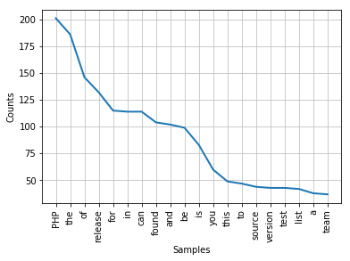

```python
freq.plot(20, cumulative=False)
```

## Word and Sentence Tokenization with NLTK

Word tokenitazion through NLTK is an improvement compare to the basic function Split NLTK provide a function that can recognize in a better way each word in a sentence.

```python
from nltk.tokenize import word_tokenize

mytext = "Hello Mr. Adam, how are you? I hope everything is going well. Today is a good day, see you dude."
print(word_tokenize(mytext))
```

```
['Hello', 'Mr.', 'Adam', ',', 'how', 'are', 'you', '?', 'I', 'hope', 'everything', 'is', 'going', 'well', '.', 'Today', 'is', 'a', 'good', 'day', ',', 'see', 'you', 'dude', '.']
```

Words like "Mr." can be easly recognize thanks to NLTK. Also it recognize punctuation as a word.

NLTK can also recognize sentenses in a text. Let see how it works.

```python
from nltk.tokenize import sent_tokenize

mytext = "Hello Adam, how are you? I hope everything is going well. Today is a good day, see you dude."
print(sent_tokenize(mytext))
```

```
['Hello Adam, how are you?', 'I hope everything is going well.', 'Today is a good day, see you dude.']
```

You can think that this is easy and you don't need NLTK to get the same results because you can divide sentenses using regular expressions given that every sentense is separated by a dot and a space. Let's see something different.

```python
from nltk.tokenize import sent_tokenize

mytext = "Hello Mr. Adam, how are you? I hope everything is going well. Today is a good day, see you dude."
print(sent_tokenize(mytext))
```

```
['Hello Mr. Adam, how are you?', 'I hope everything is going well.', 'Today is a good day, see you dude.']
```

In this case NLTK recognize the first sentense until the question mark, considering the word "Mr." as part of the sentense

## Tokenize text in other languages

NLTK can tokenize text in different languages. Please refer to NLTK documentation to find all available languages.

```python
from nltk.tokenize import sent_tokenize

mytext = "Bonjour M. Adam, comment allez-vous? J'espère que tout va bien. Aujourd'hui est un bon jour."
print(sent_tokenize(mytext,"french"))
```

```
['Bonjour M. Adam, comment allez-vous?', "J'espère que tout va bien.", "Aujourd'hui est un bon jour."]
```

## Definitions, Synonyms and Antonyms from WordNet

One of the packages you can download from NLTK.download() is WordNet. WordNet is a database created for NLP. It has nynonyms, antonyms and definitions.

```python
from nltk.corpus import wordnet

syn = wordnet.synsets("pain")
print(syn[0].definition())
print(syn[0].examples())
```

```
a symptom of some physical hurt or disorder
['the patient developed severe pain and distension']
```

For nynonyms you can use a code like this

```python
from nltk.corpus import wordnet

synonyms = []
for syn in wordnet.synsets('Computer'):
    for lemma in syn.lemmas():
        synonyms.append(lemma.name())

print(synonyms)
```

```
['computer', 'computing_machine', 'computing_device', 'data_processor', 'electronic_computer', 'information_processing_system', 'calculator', 'reckoner', 'figurer', 'estimator', 'computer']
```

For antonyms you can do the following:

```python
from nltk.corpus import wordnet

antonyms = []
for syn in wordnet.synsets("small"):
    for l in syn.lemmas():
        if l.antonyms():
            antonyms.append(l.antonyms()[0].name())

print(antonyms)
```

```
['large', 'big', 'big']
```

## Reference material

*When possible, provide reference material and additional information for the ones that wants to go further into the session topic.*

1. [NLTK documentation](https://www.nltk.org/)